# 2023年度労務管理論

2023-05-08 18:46:21

## 人口

## これまでのあらすじ

- Taylorの科学的管理法が生んだ人的資源管理
  - 従来よりもはるかに大量に人的資源を利用可能にする技術があらわれた!
  - 従来よりもはるかに単調な労働をもたらした!
- 人的資源は貴重：どの程度分布するか推定しないと!
  - 注意深く利用しないと枯渇する。無制限労働供給は終わった。
  - 無駄遣いはいけない。十全に活用する必要あり。

## 人口を論じる理由

- 人口は人的資源量の上限
  - 労働力人口は人的資源量の近似値
  - 資源量に応じて資源利用量・法は変わる
  - 人的資源管理は、人的資源利用法を広く論じる。レシピ本かもしれない。
- 人口構造はHRMに影響
  - 社会保障負担：高齢化は使用者医療費負担を増大
  - 人口構造：ある観点から分類した人口が占める割合 参考）産業構造

## 人口とは

- 生きている（生きていた）人間の数
  - 日本：124.47M（2022年11月。[総務省](http://www.stat.go.jp/data/jinsui/new.html)による推計）
  - 世界：8.045B（2023年。[国連](https://tokyo.unfpa.org/sites/default/files/pub-pdf/swop2023-english-230329web_0.pdf)による推計）
- 年齢階級による区分
  - 生産年齢人口：15-64歳
  - 幼年人口：0-14歳
  - 老年人口：65歳以上

## 人口推計（日本）

### *World Population Prospects*による

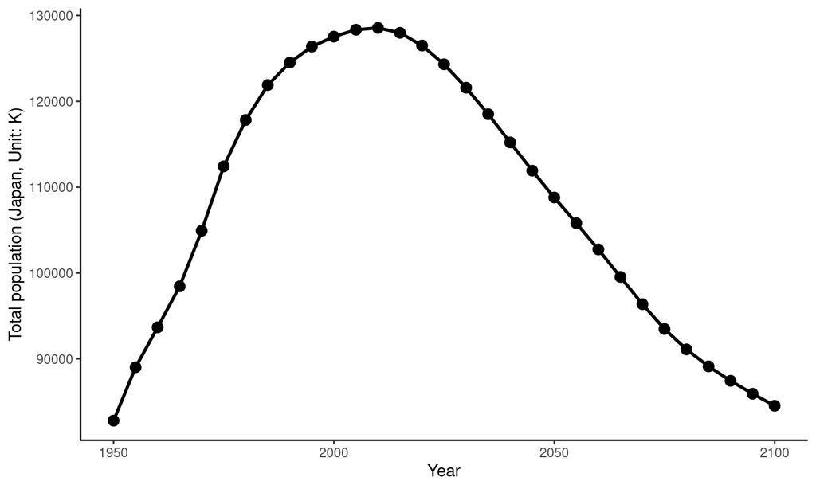

## 人口推計（ASEAN）

### *World Population Prospects*による

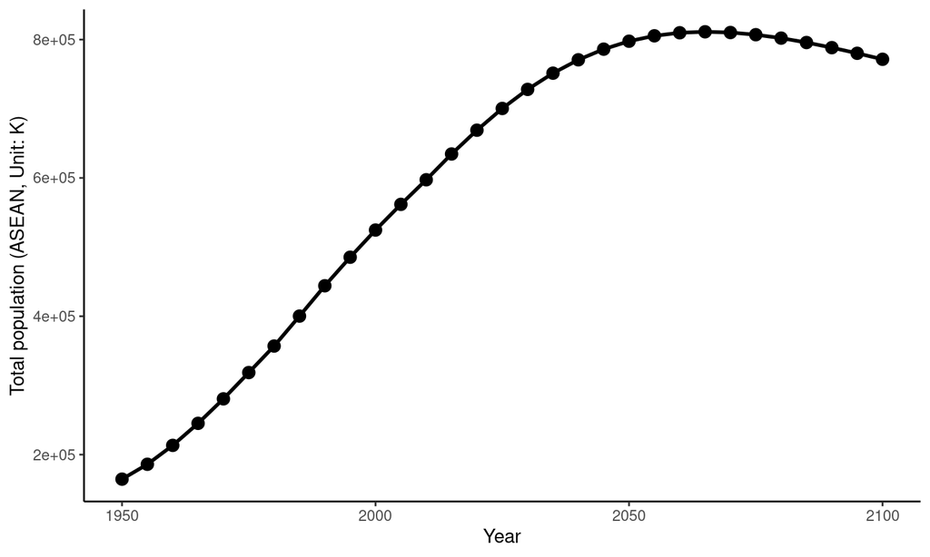

## 人口推計（アジア）

### *World Population Prospects*による

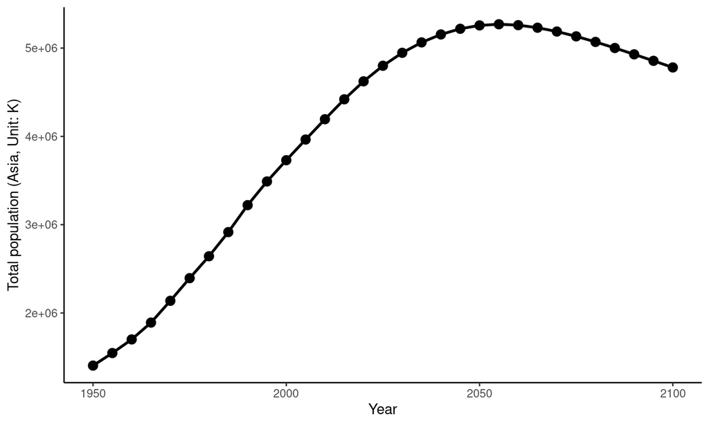

## 人口推計（世界）

### *World Population Prospects*による

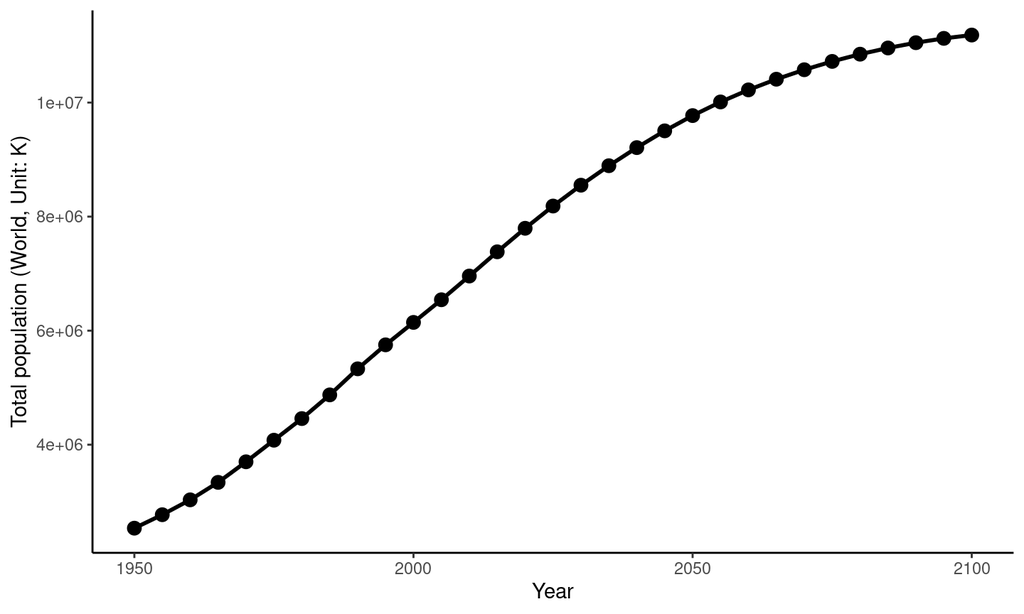

## 人口ピラミッド（日本）

### *World Population Prospects*による

[figure not shown]

## 人口ピラミッド（ASEAN）

### *World Population Prospects*による

[figure not shown]

## 人口ピラミッド（アジア）

### *World Population Prospects*による

[figure not shown]

## 人口ピラミッド（世界）

### *World Population Prospects*による

[figure not shown]

## 人口変動

## 人口変動をもたらす要因

- 4つのみ。日本全体についてはいまのところ1.と2.のみを考えればよい。
  1. 出生：生まれること
  2. 死亡：死亡すること
  3. 移入：誰かが引っ越ししてくること
  4. 移出：誰かが引っ越しして出ていくこと

## 出生と死亡だけ考えれば？

### 地域を考えると社会増を無視できない

- 出生が死亡よりも多ければ人口は増えるし、逆なら減る
- 論点
  - どの出生数（出生率）を用いるか
  - 出生率はどの程度あればよいか
  - 出生率変動をどう説明するか

## 期間合計特殊出生率

### Total Fertility Rate

- 15歳から49歳までの**母親**が産んだ子供の数。
  - 母親の年齢で調整した子供の数。
  - 配偶者がいるかは不問（配偶者有無を加味可）
  - 参考 粗出生率：\(\frac{子供の数}{人口}\)
- 定義 \[ TFR = \sum_{age=15}^{49}\frac{C_{age}}{M_{age}} \]

## 人口置換水準

- ある時点における人口を維持するために必要な出生率（子供の数）
  - 世界平均はおよそ2.1
- 乳幼児死亡率を下げる技術に依存する
  - 乳幼児期を乗り越えれば、死亡しにくいから

## 人口転換理論

- 多産多死から少産少子へ
  - 出生率と死亡率が等しくなるまでつづく
- 技術革新に依存する
  - 輸送技術、農業技術、医療技術
  - 社会経済的環境と直接には関係がない

## 図解

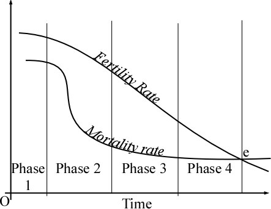

## なにがどう人口転換を促すか

### 社会経済的要因は至近要因ではない

- 輸送技術：食糧を運搬できることと人々が移動できることが、餓死を減らした。
- 農業技術：栄養状態改善→青少年死亡率減少
- 医療技術：公衆衛生改善と抗生物質発明、周産期医療改善がもたらす乳幼児と母親死亡率低下

## 人口転換理論の長短

- なんのかんので説得的。統計的によく確認できる。
- 数理的根拠はあまりない。といって経済学的解釈も生態学的解釈もナンセンスなものが多い。
- 技術進歩が人口転換をもたらす?!
  - 文化的な均一さが影響するかもしれない
  - 予測が困難

## 第二の人口転換

- 下げ止まらない出生率がもたらす人口減少
- 子供は費用でしかない
  - 子供を持つことによって得られる便益は勘案しない
  - 費用はたしかにかかるが、費用を補填しても第二の人口転換が終息するかは不明

## 安定人口理論

- 数理的裏付けがある人口理論：ロトカの積分方程式
- ある時点\(t\)における人口\(B(t)\)は、以下にて表現できる。
  - \(B(t)\):\(t\)時点における出生者数=人口
  - \(B(t-a)\):\(a\)歳の人々（コーホート）の人口増加率
  - \(p(a)\):\(a\)歳までの出生率
  - \(m(a)\):\(a\)歳の人々の生残率

\[ B(t) = \int_{0}^{t} B(t-a)p(a)m(a) da \]

## マルサス型成長\(B(t) = Be^{\rho t}\)を加味

- 内的自然成長率\(r\)にしたがって、人口は指数成長/減少。
  - \(p(a)\)が\(m(a)\)が一定である場合
  - 多少変動しても、すぐに挽回して成長/減少するので「安定」

\[ \int_{0}^{t}e^{\rho t}p(a)m(a)da = 1 \\ さらに整理して、\\ \int_{\alpha}^{\beta}e^{-r a}p(a)m(a)da = 1 \]

## 結局、人口はどう推移するか

- 推移に作用する要因は明らかになりつつある
- 統計的に予測することはできる
  - 人口推計は不思議にあたる
  - 労働力人口はおおむね人口とシンクロして増減する
  - 今後も労働力人口とシンクロするだろうか

## 参考文献

- P. モーランド、渡会圭子訳(2023)『人口で語る世界史』文藝春秋。
  - 文庫で読める人口学読み物。概念解説は少なめ。
  - 人口と経済活動について、より踏み込んで議論している。双方は関連があるらしい。
- 河野稠果(2007)『人口学への招待』中央公論新社。
  - 人口学について学ぶ入り口にはぴったり。社会経済的側面からの記述も多い
  - 理論的背景や歴史については別の文献をおすすめする

## クイズ

### 2023年5月09日12時20分締切。要長大Googleアカウント。

[figure not shown]